# Statistical Methods for Insurance: Randomisation

W1.C1

## Overview of the class

- Topics
- Assessment
- Resources
- Instructors, tutors

## Topics

- Topic 1: Simulation of games for decision strategies (2 weeks))
- Topic 2: Statistical distributions for decision theory (1.5 weeks)
- Topic 3: Linear models for credibility theory (1.5 weeks)
- Topic 4: Compiling data to problem solve (2 weeks)
- Topic 5: Bayesian statistical thinking (1.5 weeks)
- Topic 6: Temporal data and time series models
- Topic 7: Modeling risk and loss, with data and using randomization to assess uncertainty (2 weeks)

## Assessment

- Final exam: 70%
- Tutorials/labs: 25%, Weekly reports due Monday noon after the lab
- Class exercises: 5%
- ETC5242 students: Labs 15%, Project report and presentation 10%

## Resources

- Web site: http://dicook.github.io/Statistical_Thinking/
- Moodle
- [Statistics online textbook](https://www.openintro.org/stat/textbook.php?stat_book=isrs)
- [Accuarial online curriculum/exam material](https://www.actuaries.org.uk/studying/plan-my-study-route/fellowshipassociateship/core-technical-subjects/ct6-statistical-methods)
- Software: [R](https://cran.r-project.org), [RStudio Desktop](https://www.rstudio.com/products/rstudio/download2/)

## Instructors

- Instructors:
  - Professor Di Cook
  - Dr Souhaib Ben Taieb
- Tutors:
  - Earo Wang (working with Di on PhD)
  - Nathaniel Tomasetti (worked with Di for Honors, working with Dr Catherine Forbes on PhD)

## What is randomness?

- Coin flip
- Die roll
- Your sporting team wins
- Gender of a baby
- Rain tomorrow
- Stock price in an hour from now
- Lightning strike
- Pipe burst

## Your turn

We are going to play a game of "Stump the Professor".

1. Flip a coin. If it shows up tails do A first, if it shows up heads to B first.

`A. Write down a sequence of heads and tails that you might expect to come from TEN flips of a coin`

`B. Now flip a coin TEN times, and write down the outcomes`

1. Enter these in the online sheet at http://bit.ly/ETC2420-1 (Remember whether you entered the coin flip sequence first or the made up sequence.)
2. Now I am going to look at what you entered, and guess if sequence was made up, or actual outcomes from coin flips.
3. You record how many times I get it right.

## Example: a look at the Australian electoral distribution

- Results of 2013 election from Australian Electoral Commission web site
- 2011 Census data from the Australian Bureau of Statistics
- Combined demographics of electorate with political representation
- Interactive application, in R package `eechidna`

## How to use randomization to understand probability

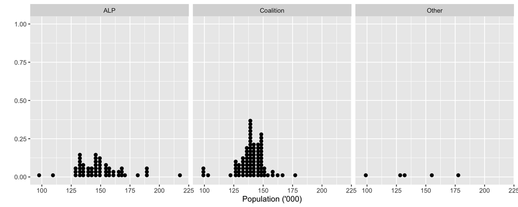

## Your turn

- What is the difference (roughly) in population between the biggest and smallest electorates?
- What is the relative worth of a voter in the electorate with the largest population, compared to a voter in the electorate with the smallest population?

## Politics

- Ideally all electorates have exactly the same number of people.
- Geography can interfere with this, e.g an electorate cannot be part in Tasmania and part in Victoria.
- The Australian Electoral Commission will adjust geographic boundaries before each election to adjust for population changes as measured in the most recent Census.

## Compute averages

```
#> # A tibble: 2 x 3
#>     PartyGp      m     s
#>       <chr>  <dbl> <dbl>
#> 1       ALP 149245 20167
#> 2 Coalition 139534 12476
```

## Statistical thinking

- The means are different
- How big is this difference?
- How likely is this difference to have arisen by chance?

We could use a two-sample t-test to answer these, but here is how to do the equivalent by randomization.

## Procedure

1. Compute the statistic for the data (e.g. absolute value of mean difference)
2. Shuffle the group labels (e.g. put the MP party names into a hat, mix them around, draw them and assign to new electorate)
3. Compute the statistic for this shuffled data
4. Repeat steps 2, 3 many times
5. Examine how often the value of the data statistic, or a larger value occurs

## Let's do it

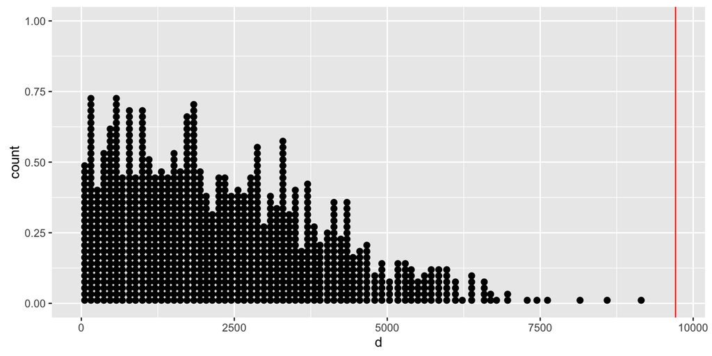

Let's also count the number of times that we see a bigger difference by chance. It is 0.

## What does this mean?

If we oberve a difference this large 0 out of 1000 random shuffles, is it likely to see this electorate distribution by chance?

## Caveats

Let's wait until the next Census results are in (after August this year) and the latest election results, to compare populations of electorates again.

## Next steps

- Next few classes we will
  - review statistical hypothesis testing
  - go through a few more examples of using permutation to make statistical significance tests
  - discuss random number generators, and simulating events
  - compute probabilities of events, and
- Lab this week will be getting started with using R - the top data science software available today.

## Share and share alike

This work is licensed under the Creative Commons Attribution-Noncommercial 3.0 United States License. To view a copy of this license, visit http://creativecommons.org/licenses/by-nc/ 3.0/us/ or send a letter to Creative Commons, 171 Second Street, Suite 300, San Francisco, California, 94105, USA.